# LASSO

機械学習

[川田恵介](https://github.com/tetokawata/TargetML)

keisukekawata@iss.u-tokyo.ac.jp

東京大学

2025-10-01

# LASSO

## 目標

- データ主導の線型モデルの推定方法を学ぶ
  - 代表的な手法であるLASSOを紹介
- “モデルの複雑性を調整する”というイメージを把握する

## 復習

- 予測モデルの構築: データをモデルに変換する
  - 変換 $=$ 推定/学習
- 変換手順は、人間が決める必要がある
  - 変換手順 $=$ 定式化と推定方法/アルゴリズム

```
flowchart LR
  D[データ] --> |投入| A[推定方法] --> |推定| M[予測モデル]
```

## 定式化の例: ベンチマーク

- $$Price\simeq\beta_0 + \beta_1\times \underbrace{RoomNumber}_{部屋数}$$

## 定式化の例: より単純なモデル

- $$Price\simeq\beta_0$$
  - $\beta_1=0$ と”人間”が決めている $\rightarrow$ データに決めさせる部分が減っている
    - $\beta_0= Price$ の単純平均 (東京全体での平均価格)が予測”モデル”となる

## 定式化の例: より複雑なモデル

- $$Price\simeq\beta_0 + \beta_1\times RoomNumber + \beta_2\times RoomNumber^2$$
  $$+\beta_3\times RoomNumber^3$$
- $\beta_2=\beta_3=0$ と”人間”が決れば、ベースモデルと一致
  - より多くをデータに決定させる定式化

## 定式化の例: 凄く複雑なモデル

- $$Price\simeq\beta_0 + \beta_1\times RoomNumber + \beta_2\times RoomNumber^2$$
  $$+\beta_3\times RoomNumber^3 + \beta_4\times RoomNumber^4$$
- $\beta_4=0$ と”人間”が決れば、より複雑なモデルと一致

## 例: ベンチマーク

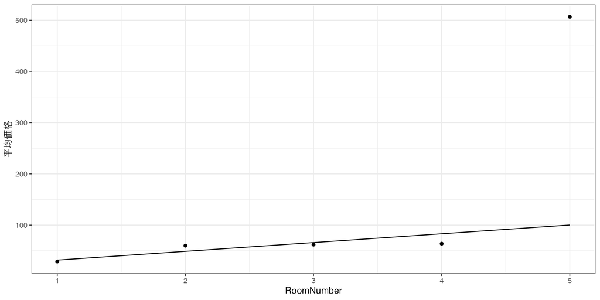

- ５部屋物件の予測価格 $\simeq 100$

## 例: 単純なモデル

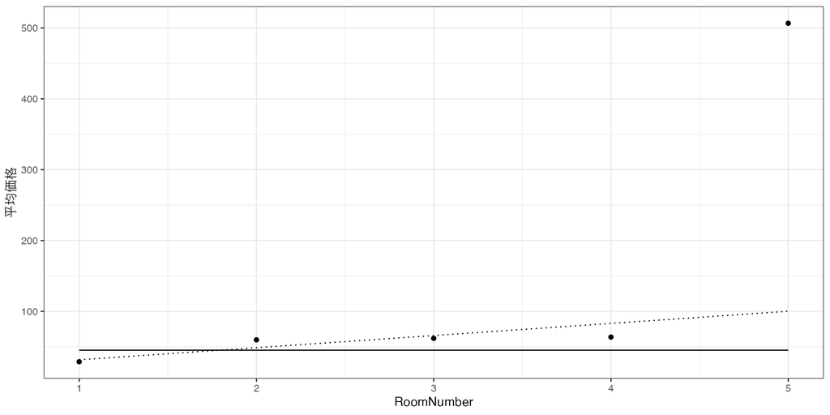

- ５部屋物件の予測価格 $\simeq 45$

## 例: 複雑なモデル

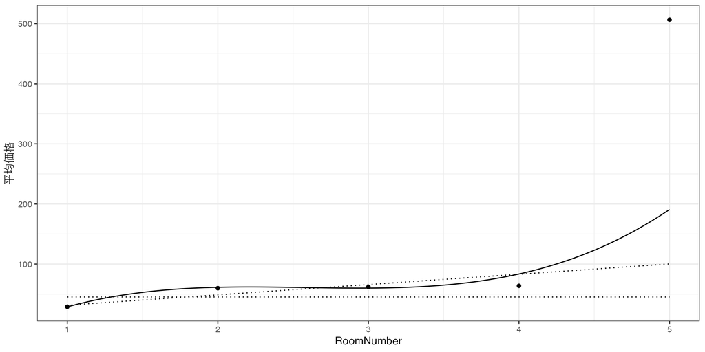

- ５部屋物件の予測価格 $\simeq 191$

## 例: 凄く複雑なモデル

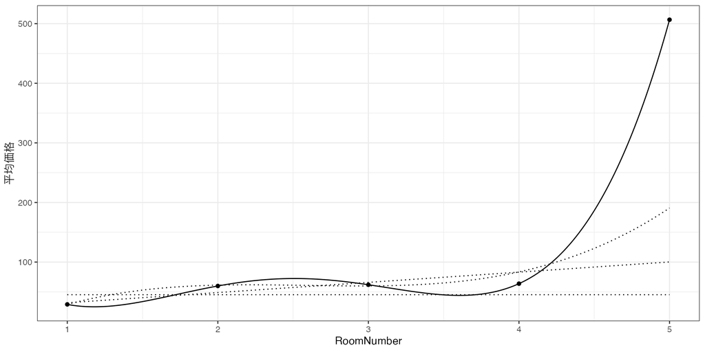

- ５部屋物件の予測価格 $\simeq 507$

## 過剰適合/過学習

- 複雑なモデルは、より多くをデータが決定し、データ上の平均値とモデルが完全一致している
  - データに最も適合するが、、、
    - 予測性能が低いケースが多い
- **過学習/過剰適合:** モデルが、データと過度に適合する(事例から過度に学び過ぎてしまう)現象
  - 非常に少数の事例から生じたデータ特徴も、モデルに反映してしまう
    - 5部屋の物件は3事例しか存在しない

# 複雑性への罰則

## 目標

- データにより多くのことを決めさせるには、複雑なモデルを推定する必要がある
  - 複雑なモデルをOLS推定すると、データへの過剰適合が生じる
- 複雑なモデルを「データに程よく適合させたい」

## 例え話

- 入門経済学: 生産方法を企業の自主的な意思決定に任せると
  - 同じ生産量を達成する方法の中で、最も費用が少ない方法が選ばれる
    - 希少な資源の利用を減らせ、それなりに望ましい
  - 一般に”負の外部性”が生じる
    - 温室効果ガスの過剰排出等
  - 社会的に望ましい水準に誘導するための政策が必要
    - 総量規制、環境税、補助金等

## 罰則付き回帰

- 線型モデル $Y\simeq\beta_0 +\beta_1X_1+..$ を推定
- 以下を最小にするように$\beta$を推定
  $$\underbrace{データへの不適合度}_{(Y-予測値)^2のデータ上の平均} + 複雑性への罰則$$

## OLSの再解釈

- OLS: 以下を最小にするように推定
  $$データへの不適合度$$
- 定式化を前提に、データへの適合**のみ**を目指す推定方法
  - 過剰適合の原因

## 罰則の定式化

- $$複雑性への罰則=\underbrace{\lambda}_{税率}\times 複雑性の測定値$$
  - LASSOにおいては、
    $$複雑性の測定値=|\beta_1|+|\beta_2|..$$
- $\lambda$ は予測性能が良くなりそうな値を設定する
  - いろいろな方法が提案されている
  - 本講義では、hdm packageで実装されている理論的指標を用いる

## $\lambda$ の影響

- 最も単純なモデル (複雑性の測定値 $=$ 0)は、
  $$\beta_1=\beta_2=..=0$$
  - $Y\simeq \beta_0=単純平均$
- $|\beta_1|$ が大きくなれば、予測値が $X_1$ により反応する
  - より複雑な予測モデル

## $\lambda$ の影響

- $\lambda\rightarrow\infty$ であれば、複雑性の低下が最優先
  - $\beta_1=\beta_2=..=0$
  - 予測モデル $=$ 単純平均

## $\lambda$ の影響

- $\lambda=0$ であれば、データへの当てはまりのみを追求
  - OLS!!!
  - 予測モデル $=$ OLSで推定されたモデル

## 例

```r
hdm::rlasso(Price ~ Size + Tenure + Distance + District, data, post = FALSE)
```

```
Call:
rlasso.formula(formula = Price ~ Size + Tenure + Distance + District,
    data = data, post = FALSE)

Coefficients:
     (Intercept)              Size            Tenure          Distance
         15.2453            1.1703           -0.6395           -0.9943
  District中央区    District中野区      District北区  District千代田区
          2.8331            0.0000          -13.0874           18.3989
  District台東区    District品川区    District大田区    District文京区
         -4.2591            0.6435           -8.3461            0.3467
  District新宿区    District杉並区    District板橋区  District江戸川区
          3.4565            0.0000          -15.6118          -26.6841
  District江東区    District渋谷区      District港区    District目黒区
         -9.8651           15.1645           32.4377            8.7597
  District練馬区    District荒川区    District葛飾区    District豊島区
        -15.0456          -18.2211          -22.4133           -0.7486
  District足立区    District墨田区
        -23.5088           -9.4562
```

## 例: OLS

```r
lm(Price ~ Size + Tenure + Distance + District, data)
```

```
Call:
lm(formula = Price ~ Size + Tenure + Distance + District, data = data)

Coefficients:
     (Intercept)              Size            Tenure          Distance
          9.9762            1.2373           -0.6782           -1.0522
  District中央区    District中野区      District北区  District千代田区
          7.4307            2.1518          -11.3431           28.5354
  District台東区    District品川区    District大田区    District文京区
         -2.3232            5.8732           -5.3455            5.4088
  District新宿区    District杉並区    District板橋区  District江戸川区
          8.6121            1.7546          -13.2401          -25.5362
  District江東区    District渋谷区      District港区    District目黒区
         -8.0226           24.2997           41.3445           15.7670
  District練馬区    District荒川区    District葛飾区    District豊島区
        -12.8446          -16.9899          -20.9135            1.7057
  District足立区    District墨田区
        -21.9901           -6.8787
```

## 例

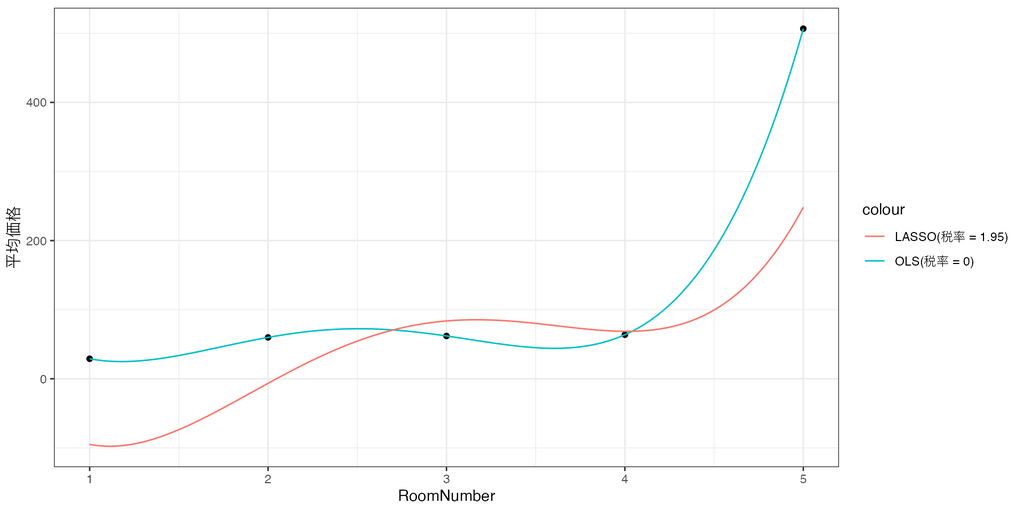

## 例

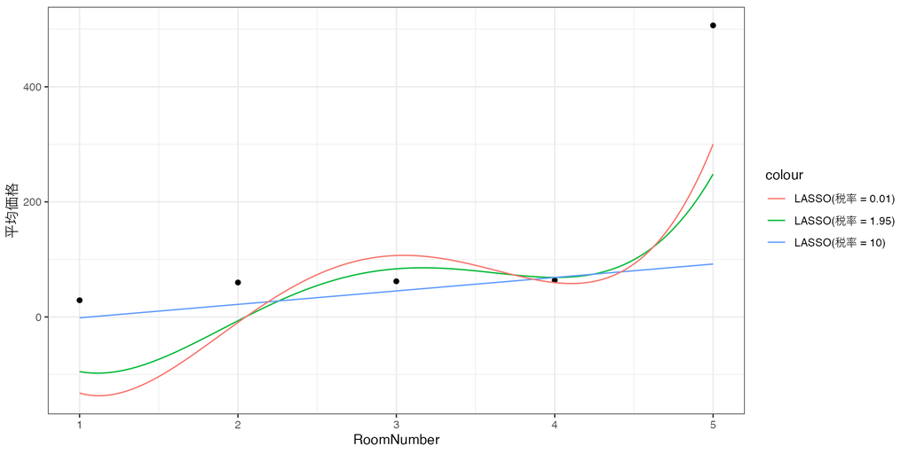

## LASSOの性質: 変数選択

- LASSOの重要な性質は変数選択
  - モデルから変数を除外する
- 例: モデル
  $$Price\simeq\beta_0+\beta_1Size+\beta_2Tenure$$
  から、Tenureを除外する
  - $$Price\simeq\beta_0+\beta_1Size+\underbrace{\beta_2}_{=0}Tenure$$

## LASSOの性質

- 罰則の定式化より、$\beta$ の推定値が厳密に0となりうる
  - 該当する変数が除外される
- OLSなど他の推定方法では、一般に厳密に0とはならない
  - 変数が除外されない
    - 除外したいのであれば、人間が推定前に除外しないといけない
- LASSOは、“データ主導の変数選択”を行う

## Takeaway

- 一般に、OLSは複雑なモデルの推定が苦手
  - 過剰適合を避けるために、多くの事例数を要求
    - 経験則として、$\beta$ の数が事例数の1/3を超えると予測性能が悪化しやすい
- 機械学習 $=$ 複雑なモデルを、過剰適合を避けながら推定する方法を提案
  - LASSOは代表格